# Bonus Lab 1: Introduction to Deep Learning and Neural Networks in R and Python

Author

Dr. Derrick L. Cogburn

Published

November 15, 2024

# Lab Overview

## Technical Learning Objectives

1. Understand the fundamental concepts of deep learning.
2. Compare traditional ML with deep learning approaches
3. Understand and implement the basic structure of a neural network.
4. Practice with neural networks in R and Python.

## Business Learning Objectives

1. Understand the potential of deep learning for predictive analytics.
2. Understand the limitations of deep learning.
3. Understand the potential of deep learning for text analysis.
4. Understand the potential of deep learning for image analysis.

# Assignment Overview

In this bonus lab we introduce the concept of deep learning and neural networks. We will compare traditional machine learning with deep learning approaches. We will also introduce the basic structure of a neural network and practice with neural networks in R and Python.

Exercise 1: Buiulding a Simple Neural Network in R (Keras)

Exercise 3: Practical Application of a Neural Network in R (Keras): Digit Classifier

# **Lab Instructions**

Make sure you have the following packages installed in R and Python: keras, tensorflow, tidyverse, quanteda, readtext, stm, stminsights, wordcloud, gsl, topicmodels, caret, gutenbergr.

## **Exercise 1: Building a Simple Neural Network in R (Keras)**

```r
library(keras)
library(tidyverse)
# Create a simple sequential model
model <- keras_model_sequential() %>%
  layer_dense(units = 64, activation = 'relu', input_shape = c(10)) %>%
  layer_dense(units = 32, activation = 'relu') %>%
  layer_dense(units = 1, activation = 'sigmoid')

# Compile the model
model %>% compile(
  optimizer = 'adam',
  loss = 'binary_crossentropy',
  metrics = c('accuracy')
)
# Then look at the model, and its three layers
model
```

```
Model: "sequential"
________________________________________________________________________________
 Layer (type)                       Output Shape                    Param #
================================================================================
 dense_2 (Dense)                    (None, 64)                      704
 dense_1 (Dense)                    (None, 32)                      2080
 dense (Dense)                      (None, 1)                       33
================================================================================
Total params: 2,817
Trainable params: 2,817
Non-trainable params: 0
________________________________________________________________________________
```

## **Exercise 2: Building an Intuitive Neural Network in R (Keras)**

Let’s now take this a little further by building an intuitive neural network

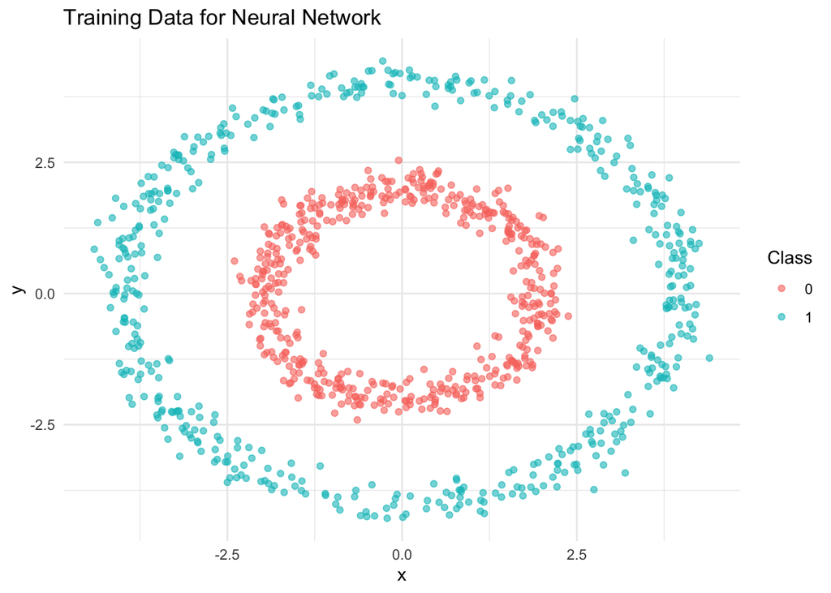

```r
library(keras)
library(tidyverse)
library(ggplot2)

# Create synthetic dataset
set.seed(123)
n_points <- 1000

# Generate two circular clusters
create_circular_data <- function(n_points) {
  # Create cluster 1
  theta1 <- runif(n_points/2, 0, 2*pi)
  r1 <- rnorm(n_points/2, mean=2, sd=0.2)
  x1 <- r1 * cos(theta1)
  y1 <- r1 * sin(theta1)

  # Create cluster 2
  theta2 <- runif(n_points/2, 0, 2*pi)
  r2 <- rnorm(n_points/2, mean=4, sd=0.2)
  x2 <- r2 * cos(theta2)
  y2 <- r2 * sin(theta2)

  # Combine data
  data.frame(
    x = c(x1, x2),
    y = c(y1, y2),
    label = c(rep(0, n_points/2), rep(1, n_points/2))
  )
}

# Generate and visualize data
df <- create_circular_data(n_points)

# Visualize the data
ggplot(df, aes(x=x, y=y, color=factor(label))) +
  geom_point(alpha=0.6) +
  theme_minimal() +
  labs(title="Training Data for Neural Network",
       color="Class")
```

[output not shown]

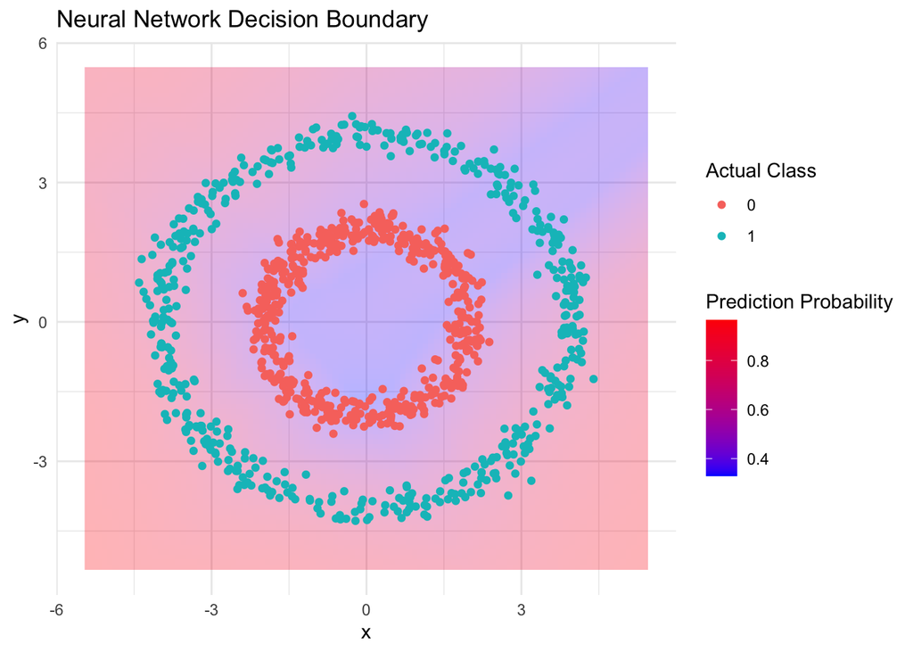

```r
# Create and compile model
model <- keras_model_sequential() %>%
  layer_dense(units=8, activation='relu', input_shape=c(2)) %>%
  layer_dense(units=4, activation='relu') %>%
  layer_dense(units=1, activation='sigmoid')

model %>% compile(
  optimizer = 'adam',
  loss = 'binary_crossentropy',
  metrics = c('accuracy')
)

# Prepare data for training
x_train <- as.matrix(df[, c("x", "y")])
y_train <- df$label

# Train model
history <- model %>% fit(
  x_train, y_train,
  epochs = 20,
  validation_split = 0.2,
  verbose = 1
)
# Visualize decision boundaries
create_decision_boundary <- function(model, df) {
  # Create grid of points
  x_range <- seq(min(df$x) - 1, max(df$x) + 1, length.out = 100)
  y_range <- seq(min(df$y) - 1, max(df$y) + 1, length.out = 100)
  grid <- expand.grid(x = x_range, y = y_range)

  # Get predictions
  predictions <- predict(model, as.matrix(grid))

  # Create visualization
  grid$pred <- as.vector(predictions)

  ggplot() +
    geom_raster(data=grid, aes(x=x, y=y, fill=pred), alpha=0.3) +
    geom_point(data=df, aes(x=x, y=y, color=factor(label))) +
    scale_fill_gradient(low="blue", high="red") +
    theme_minimal() +
    labs(title="Neural Network Decision Boundary",
         fill="Prediction Probability",
         color="Actual Class")
}

# Visualize the decision boundary
create_decision_boundary(model, df)
```

## **Exercise 3: Building a Practical Application of a Neural Network in R (Keras)**

Now, we can take a look at a practical application of a neural network in R.

```r
# Load MNIST dataset
mnist <- dataset_mnist()
x_train <- mnist$train$x
y_train <- mnist$train$y

# Preprocess data
x_train <- array_reshape(x_train, c(nrow(x_train), 784))
x_train <- x_train / 255

# Create model
model <- keras_model_sequential() %>%
  layer_dense(units = 128, activation = 'relu', input_shape = c(784)) %>%
  layer_dropout(0.3) %>%
  layer_dense(units = 10, activation = 'softmax')

model
```

```
Model: "sequential_2"
________________________________________________________________________________
 Layer (type)                       Output Shape                    Param #
================================================================================
 dense_7 (Dense)                    (None, 128)                     100480
 dropout (Dropout)                  (None, 128)                     0
 dense_6 (Dense)                    (None, 10)                      1290
================================================================================
Total params: 101,770
Trainable params: 101,770
Non-trainable params: 0
________________________________________________________________________________
```

Now, let’s take a look at buiding a simple neural network in Python.

```python
import tensorflow as tf
from tensorflow.keras import layers, models

# Create a similar model in Python
model = models.Sequential([
    layers.Dense(64, activation='relu', input_shape=(10,)),
    layers.Dense(32, activation='relu'),
    layers.Dense(1, activation='sigmoid')
])

# Compile the model
model.compile(
    optimizer='adam',
    loss='binary_crossentropy',
    metrics=['accuracy']
)
```

## **Exercise 5: Building and Visualizing an Intuitive Neural Network in Python**

As before, let’s now take this a bit further in Python by building an intuitive neural network.

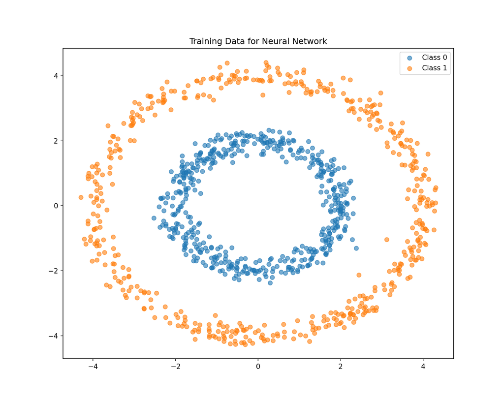

```python
import numpy as np
import tensorflow as tf
from tensorflow.keras import layers, models
import matplotlib.pyplot as plt
import seaborn as sns

# Create synthetic dataset
np.random.seed(123)
n_points = 1000

def create_circular_data(n_points):
    # Create cluster 1
    theta1 = np.random.uniform(0, 2*np.pi, n_points//2)
    r1 = np.random.normal(2, 0.2, n_points//2)
    x1 = r1 * np.cos(theta1)
    y1 = r1 * np.sin(theta1)

    # Create cluster 2
    theta2 = np.random.uniform(0, 2*np.pi, n_points//2)
    r2 = np.random.normal(4, 0.2, n_points//2)
    x2 = r2 * np.cos(theta2)
    y2 = r2 * np.sin(theta2)

    X = np.vstack([np.column_stack((x1, y1)),
                  np.column_stack((x2, y2))])
    y = np.hstack([np.zeros(n_points//2),
                  np.ones(n_points//2)])

    return X, y

# Generate data
X, y = create_circular_data(n_points)

# Visualize data
plt.figure(figsize=(10, 8))
plt.scatter(X[y==0, 0], X[y==0, 1], label='Class 0', alpha=0.6)
plt.scatter(X[y==1, 0], X[y==1, 1], label='Class 1', alpha=0.6)
plt.title('Training Data for Neural Network')
plt.legend()
plt.show()
```

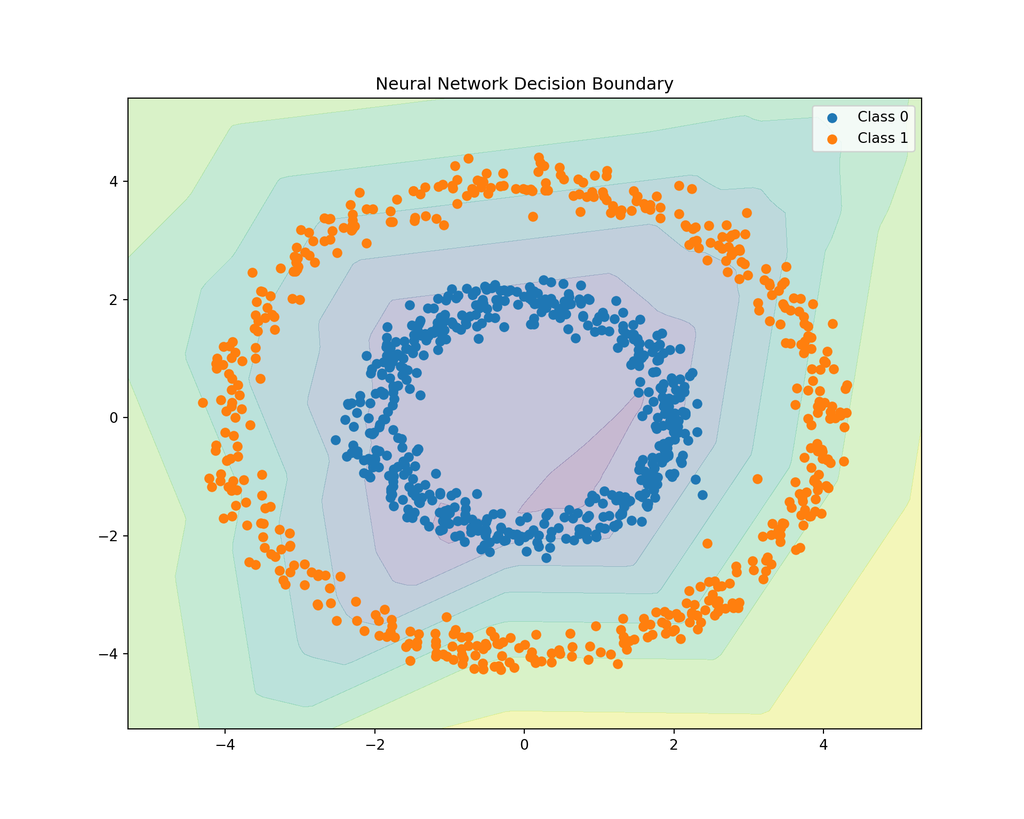

```python
# Create model
model = models.Sequential([
    layers.Dense(8, activation='relu', input_shape=(2,)),
    layers.Dense(4, activation='relu'),
    layers.Dense(1, activation='sigmoid')
])

model.compile(
    optimizer='adam',
    loss='binary_crossentropy',
    metrics=['accuracy']
)

# Train model
history = model.fit(
    X, y,
    epochs=20,
    validation_split=0.2,
    verbose=1
)
# Function to plot decision boundary
def plot_decision_boundary(model, X, y):
    x_min, x_max = X[:, 0].min() - 1, X[:, 0].max() + 1
    y_min, y_max = X[:, 1].min() - 1, X[:, 1].max() + 1
    xx, yy = np.meshgrid(np.linspace(x_min, x_max, 100),
                        np.linspace(y_min, y_max, 100))

    # Get predictions
    Z = model.predict(np.c_[xx.ravel(), yy.ravel()])
    Z = Z.reshape(xx.shape)

    # Plot
    plt.figure(figsize=(10, 8))
    plt.contourf(xx, yy, Z, alpha=0.3)
    plt.scatter(X[y==0, 0], X[y==0, 1], label='Class 0')
    plt.scatter(X[y==1, 0], X[y==1, 1], label='Class 1')
    plt.title('Neural Network Decision Boundary')
    plt.legend()
    plt.show()

# Visualize decision boundary
plot_decision_boundary(model, X, y)
```